# Reproducible Research: Peer Assessment 1

## Loading and preprocessing the data

```r
library(dplyr)
library(lubridate)
```

```r
library(ggplot2)
```

```r
if (!file.exists("activity.csv") ) {
        unzip("activity.zip")
}
activity <- read.csv("activity.csv", header = TRUE)

activity$date <- as.Date(activity$date)
head(activity)
```

```
##   steps       date interval
## 1    NA 2012-10-01        0
## 2    NA 2012-10-01        5
## 3    NA 2012-10-01       10
## 4    NA 2012-10-01       15
## 5    NA 2012-10-01       20
## 6    NA 2012-10-01       25
```

## What is mean total number of steps taken per day?

```r
#  ignore the missing values in the dataset:
NumberStepsPerDay <- activity %>%
        group_by(date) %>%
        summarize(TotalSteps = sum(steps, na.rm = TRUE))

head(NumberStepsPerDay)
```

```
## # A tibble: 6 × 2
##   date       TotalSteps
##   <date>          <int>
## 1 2012-10-01          0
## 2 2012-10-02        126
## 3 2012-10-03      11352
## 4 2012-10-04      12116
## 5 2012-10-05      13294
## 6 2012-10-06      15420
```

1. Make a histogram of the total number of steps taken each day:

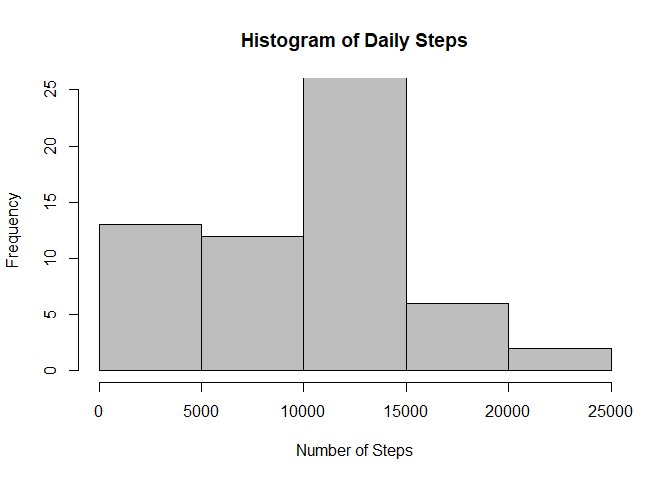

```r
hist(NumberStepsPerDay$TotalSteps, main = "Histogram of Daily Steps",
     col="grey", xlab="Number of Steps", ylim = c(0,25))
```

2. Calculate and report the mean and median total number of steps taken each day:

```r
MeanNumberStepsPerDay <- round(mean(NumberStepsPerDay$TotalSteps))
print(paste("The mean total number of steps taken each day is: ", MeanNumberStepsPerDay))
```

```
## [1] "The mean total number of steps taken each day is:  9354"
```

```r
MedianNumberStepsPerDay <- round(median(NumberStepsPerDay$TotalSteps))
print(paste("The median total number of steps taken each day is: ", MedianNumberStepsPerDay))
```

```
## [1] "The median total number of steps taken each day is:  10395"
```

## What is the average daily activity pattern?

1. Make a timeseries plot (i.e. type=“l”), of the 5-minutes interval (x-axis) and the average number of steps taken, averaged across all days (y-axis)

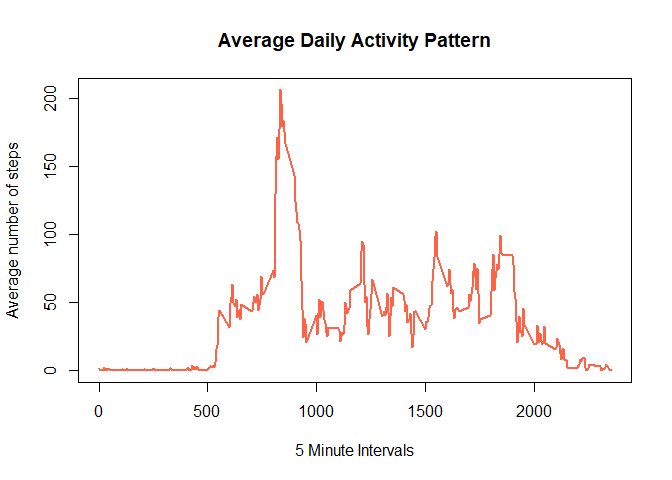

```r
stepsPerInterval <- activity %>%
        group_by(interval) %>%
        summarize(meansteps = mean(steps, na.rm = TRUE))

plot(stepsPerInterval$meansteps ~ stepsPerInterval$interval,
     col="tomato", lwd = 2, type="l", xlab = "5 Minute Intervals", ylab = "Average number of steps",
     main = "Average Daily Activity Pattern")
```

2. Which 5-minute interval, on average across all the days in the dataset, contains the maximum number of steps?

-Get the most active 5-minute interval

```r
max_index <- which.max(stepsPerInterval$meansteps)
max_interval <- stepsPerInterval$interval[max_index]

print(paste("Interval containing the most active 5-minute interval steps on average: ",max_interval))
```

```
## [1] "Interval containing the most active 5-minute interval steps on average:  835"
```

## Imputing missing values

1. Calculate and report the total number of missing values in dataset (i.e the total number of rows with NAs)

```r
print(paste("The total number of missing values in dataset is: ",sum(is.na(activity$steps))))
```

```
## [1] "The total number of missing values in dataset is:  2304"
```

2. Devise a strategy for filling in all of the missing values in the dataset.

Approach - Replace each missing value with the average value of its corresponding 5-minute interval. To do that, the average daily activity ( stepsPerInterval ) that was computed will be used here. We will iterate through all rows in the “activity” data and look for the NA values entries. Once found we will update its Steps’s values by the one that corresponds in the “stepsPerInterval”.

```r
#Create a new dataset that is equal to the original dataset but with the missing data filled in.
new_activity <- activity

for (i in 1:nrow(activity))
{
  if( !is.na(activity$steps[i]))
  {
    next
  }
  new_activity$steps[i]<- stepsPerInterval$meansteps[new_activity$interval[i] == stepsPerInterval$interval]

}
head(activity)
```

```
##   steps       date interval
## 1    NA 2012-10-01        0
## 2    NA 2012-10-01        5
## 3    NA 2012-10-01       10
## 4    NA 2012-10-01       15
## 5    NA 2012-10-01       20
## 6    NA 2012-10-01       25
```

```r
head(new_activity)
```

```
##       steps       date interval
## 1 1.7169811 2012-10-01        0
## 2 0.3396226 2012-10-01        5
## 3 0.1320755 2012-10-01       10
## 4 0.1509434 2012-10-01       15
## 5 0.0754717 2012-10-01       20
## 6 2.0943396 2012-10-01       25
```

4. Make a histogram of the total number of steps taken each day and Calculate and report the mean and median total number of steps taken per day. Do these values differ from the estimates from the first part of the assignment? What is the impact of imputing missing data on the estimates of the total daily number of steps?

```r
NewNumberStepsPerDay <- new_activity %>%
        group_by(date) %>%
        summarize(TotalSteps = sum(steps, na.rm = TRUE ) )

head(NewNumberStepsPerDay)
```

```
## # A tibble: 6 × 2
##   date       TotalSteps
##   <date>          <dbl>
## 1 2012-10-01     10766.
## 2 2012-10-02       126
## 3 2012-10-03     11352
## 4 2012-10-04     12116
## 5 2012-10-05     13294
## 6 2012-10-06     15420
```

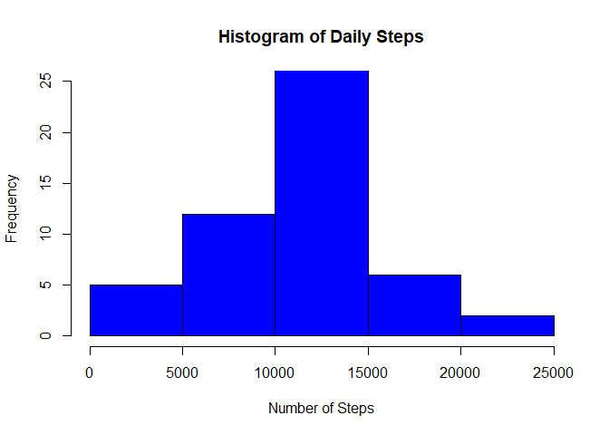

```r
hist(NewNumberStepsPerDay$TotalSteps, main = "Histogram of Daily Steps",
     col="blue", xlab="Number of Steps", ylim = c(0,25))
```

In the first histogram plot, the total number of steps are set to 0s by default for the NA values. But, after filling these NA values by their average steps values, these 0 values are removed from the histogram and that why the value of number of steps in the interval [0, 5000] is reduced to the value 5.

```r
#Calculate and report the mean and median total number of steps taken each day:

MeanNewNumberStepsPerDay <- round(mean(NewNumberStepsPerDay$TotalSteps))

print(paste("The mean total number of steps taken each day, after filling the NA values, is: ", MeanNewNumberStepsPerDay))
```

```
## [1] "The mean total number of steps taken each day, after filling the NA values, is:  10766"
```

```r
MedianNewNumberStepsPerDay <- round(median(NewNumberStepsPerDay$TotalSteps))

print(paste("The median total number of steps taken each day, after filling the NA values,is: ", MedianNewNumberStepsPerDay))
```

```
## [1] "The median total number of steps taken each day, after filling the NA values,is:  10766"
```

After the missing data is filled in, the mean and median values are enhanced. This resulted from the NA values being set to 0, which have since been updated with a useful value.

## Are there differences in activity patterns between weekdays and weekends?

1. Create a new factor variable in the dataset with two levels – “weekday” and “weekend” indicating whether a given date is a weekday or weekend day.

```r
new_activity$weekday <- weekdays(new_activity$date)

new_activity$day <-
  ifelse(weekdays(new_activity$date) %in% c("Saturday", "Sunday"), "weekend", "weekday")

new_activity$day <- as.factor(new_activity$day)

head(new_activity, 20)
```

```
##        steps       date interval weekday     day
## 1  1.7169811 2012-10-01        0  Monday weekday
## 2  0.3396226 2012-10-01        5  Monday weekday
## 3  0.1320755 2012-10-01       10  Monday weekday
## 4  0.1509434 2012-10-01       15  Monday weekday
## 5  0.0754717 2012-10-01       20  Monday weekday
## 6  2.0943396 2012-10-01       25  Monday weekday
## 7  0.5283019 2012-10-01       30  Monday weekday
## 8  0.8679245 2012-10-01       35  Monday weekday
## 9  0.0000000 2012-10-01       40  Monday weekday
## 10 1.4716981 2012-10-01       45  Monday weekday
## 11 0.3018868 2012-10-01       50  Monday weekday
## 12 0.1320755 2012-10-01       55  Monday weekday
## 13 0.3207547 2012-10-01      100  Monday weekday
## 14 0.6792453 2012-10-01      105  Monday weekday
## 15 0.1509434 2012-10-01      110  Monday weekday
## 16 0.3396226 2012-10-01      115  Monday weekday
## 17 0.0000000 2012-10-01      120  Monday weekday
## 18 1.1132075 2012-10-01      125  Monday weekday
## 19 1.8301887 2012-10-01      130  Monday weekday
## 20 0.1698113 2012-10-01      135  Monday weekday
```

2. Make a panel plot containing a time series plot (i.e. type=“l”) of the 5-minute interval (x-axis) and the average number of steps taken, averaged across all weekday days or weekend days (y-axis).

```r
# split data by week day type
Weekday_activity <- filter(new_activity, new_activity$day == "weekday")
Weekend_activity <- filter(new_activity, new_activity$day == "weekend")

head(Weekend_activity, 20)
```

```
##    steps       date interval  weekday     day
## 1      0 2012-10-06        0 Saturday weekend
## 2      0 2012-10-06        5 Saturday weekend
## 3      0 2012-10-06       10 Saturday weekend
## 4      0 2012-10-06       15 Saturday weekend
## 5      0 2012-10-06       20 Saturday weekend
## 6      0 2012-10-06       25 Saturday weekend
## 7      0 2012-10-06       30 Saturday weekend
## 8      0 2012-10-06       35 Saturday weekend
## 9      0 2012-10-06       40 Saturday weekend
## 10     0 2012-10-06       45 Saturday weekend
## 11     0 2012-10-06       50 Saturday weekend
## 12     0 2012-10-06       55 Saturday weekend
## 13     0 2012-10-06      100 Saturday weekend
## 14     0 2012-10-06      105 Saturday weekend
## 15     0 2012-10-06      110 Saturday weekend
## 16     0 2012-10-06      115 Saturday weekend
## 17     0 2012-10-06      120 Saturday weekend
## 18     0 2012-10-06      125 Saturday weekend
## 19     0 2012-10-06      130 Saturday weekend
## 20     0 2012-10-06      135 Saturday weekend
```

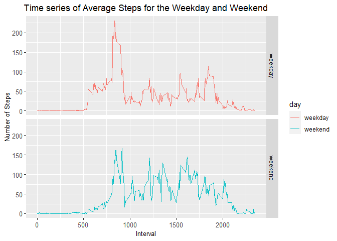

```r
Weekday_activity <- Weekday_activity %>%
        group_by(interval) %>%
        summarize(meansteps = mean(steps))

Weekday_activity$day <- "weekday"

Weekend_activity <- Weekend_activity %>%
        group_by(interval) %>%
        summarize(meansteps = mean(steps))
Weekend_activity$day <- "weekend"

Weekday_weekend_activity <- rbind(Weekday_activity, Weekend_activity)
Weekday_weekend_activity$day <- as.factor(Weekday_weekend_activity$day)

g <- ggplot (Weekday_weekend_activity, aes (interval, meansteps, color=day))
g + geom_line() + facet_grid (day~.) +
        theme(axis.text = element_text(size = 10),axis.title = element_text(size = 10)) +
        labs(y = "Number of Steps") + labs(x = "Interval") +
        ggtitle("Time series of Average Steps for the Weekday and Weekend") +
        theme(plot.title = element_text(hjust = 0.5))
```